# Random Forests Lab

## Convert data to the required format

```r
# 1: Die(+ve); 0: Live (-ve)
#data$target= ifelse(data$target==1, 1, 0 )
```

### Separate Categorical and Numerical Variables

```r
# The numerical variables are: age, bili, alk, sgot, albu and protime
# The categorical variables are: the remaining 14 variables





#num_Attr = c("age", "bili", "alk", "sgot", "albu", "protime")
#cat_Attr = setdiff(names(data), num_Attr)
#cat_Attr

cat_Attr = c("Work_related_injury_status", "Non_economicloss", "Exemplarydamages","WhetherPrimaFacie_JointandSeveralLiability","WorkersCompAvailability","CollateralSourcesAvailability",
         "MedicalInsurance","DisabilityInsurance","SocialSecurityBenefits","Medicare_Medicaid","OtherCollateralSources",
         "ClaimSize","Employment_status")
num_Attr = setdiff(names(data1), cat_Attr)
#num_Attr

# Separate numerical and categorical variables and convert them into appropriate type

cat_Data = data.frame(sapply(data1[,cat_Attr], as.factor))
num_Data = data.frame(sapply(data1[,num_Attr], as.numeric))
data2 = cbind(num_Data, cat_Data)
str(data2)
```

```
## 'data.frame':    14417 obs. of  58 variables:
##  $ Age_Injured                               : num  5800 3100 3200 6500 3800 3300 3900 1600 3400 4000 ...
##  $ Amputation                                : num  0 0 0 0 0 0 0 0 0 0 ...
##  $ Death                                     : num  0 1 0 1 0 0 1 0 0 0 ...
##  $ Burns_heat                                : num  0 0 0 0 0 0 0 0 0 0 ...
##  $ Burns_chemical                            : num  0 0 0 0 0 0 0 0 0 0 ...
##  $ SystemicPoisoning_toxic                   : num  0 0 0 0 0 0 0 0 0 0 ...
##  $ Eye_injury_blindness                      : num  0 0 0 0 0 0 0 0 0 0 ...
##  $ RespiratoryCondition                      : num  0 0 0 0 0 0 0 0 0 0 ...
##  $ NervousCondition                          : num  0 0 0 0 0 0 0 0 0 0 ...
##  $ HearingLoss                               : num  0 0 0 0 0 0 0 0 0 0 ...
##  $ CirculatoryCondition                      : num  0 0 0 0 0 0 0 0 0 0 ...
##  $ MultipleInjuries                          : num  1 0 1 1 0 0 1 0 1 0 ...
##  $ BackInjury                                : num  0 0 0 0 0 1 0 1 1 1 ...
##  $ SkinDisorder                              : num  0 0 0 0 0 0 0 0 0 0 ...
```

[output cut: 44 more lines]

```r
# Remove variable that are not needed further
#rm(num_Attr, cat_Attr)
#rm(cat_Data, num_Data)
```

## Split dataset into train and test

```r
set.seed(009)

train_RowIDs = sample(1:nrow(data2), nrow(data2)*0.7)
train_Data = data2[train_RowIDs,]
test_Data = data2[-train_RowIDs,]

rm(train_RowIDs)
```

## Check how records are split with respect to target attribute

```r
table(data$ClaimSize)
```

```
##
## 100K-lessthan200K      200KandAbove      lessthan100K
##              3768              3222              7427
```

```r
table(train_Data$ClaimSize)
```

```
##
## 100K-lessthan200K      200KandAbove      lessthan100K
##              2634              2247              5210
```

```r
table(test_Data$ClaimSize)
```

```
##
## 100K-lessthan200K      200KandAbove      lessthan100K
##              1134               975              2217
```

```r
# Note : # As part of Pre-processing, Imputation and scaling are done after train-evaluation/test split
```

## Check to see if missing values in data

```r
sum(is.na(train_Data))
```

```
## [1] 0
```

```r
sum(is.na(test_Data))
```

```
## [1] 0
```

```r
summary(train_Data)
```

```
##   Age_Injured      Amputation         Death          Burns_heat
##  Min.   : 1100   Min.   :0.0000   Min.   :0.0000   Min.   :0.00000
##  1st Qu.: 3200   1st Qu.:0.0000   1st Qu.:0.0000   1st Qu.:0.00000
##  Median : 4200   Median :0.0000   Median :0.0000   Median :0.00000
##  Mean   : 4380   Mean   :0.0106   Mean   :0.1199   Mean   :0.01358
##  3rd Qu.: 5400   3rd Qu.:0.0000   3rd Qu.:0.0000   3rd Qu.:0.00000
##  Max.   :10000   Max.   :1.0000   Max.   :1.0000   Max.   :1.00000
##  Burns_chemical     SystemicPoisoning_toxic Eye_injury_blindness
##  Min.   :0.000000   Min.   :0.000000        Min.   :0.00000
##  1st Qu.:0.000000   1st Qu.:0.000000        1st Qu.:0.00000
##  Median :0.000000   Median :0.000000        Median :0.00000
##  Mean   :0.004955   Mean   :0.003567        Mean   :0.00882
##  3rd Qu.:0.000000   3rd Qu.:0.000000        3rd Qu.:0.00000
##  Max.   :1.000000   Max.   :1.000000        Max.   :1.00000
##  RespiratoryCondition NervousCondition    HearingLoss
##  Min.   :0.000000     Min.   :0.000000   Min.   :0.000000
##  1st Qu.:0.000000     1st Qu.:0.000000   1st Qu.:0.000000
##  Median :0.000000     Median :0.000000   Median :0.000000
##  Mean   :0.007036     Mean   :0.009513   Mean   :0.004559
##  3rd Qu.:0.000000     3rd Qu.:0.000000   3rd Qu.:0.000000
##  Max.   :1.000000     Max.   :1.000000   Max.   :1.000000
##  CirculatoryCondition MultipleInjuries   BackInjury      SkinDisorder
##  Min.   :0.000000     Min.   :0.0000   Min.   :0.0000   Min.   :0.000000
##  1st Qu.:0.000000     1st Qu.:0.0000   1st Qu.:0.0000   1st Qu.:0.000000
##  Median :0.000000     Median :0.0000   Median :0.0000   Median :0.000000
##  Mean   :0.006937     Mean   :0.3548   Mean   :0.3932   Mean   :0.005748
##  3rd Qu.:0.000000     3rd Qu.:1.0000   3rd Qu.:1.0000   3rd Qu.:0.000000
##  Max.   :1.000000     Max.   :1.0000   Max.   :1.0000   Max.   :1.000000
##   BrainDamage         Scarring       SpinalCordInjuries OtherInjuries
##  Min.   :0.00000   Min.   :0.00000   Min.   :0.00000    Min.   :0.0000
##  1st Qu.:0.00000   1st Qu.:0.00000   1st Qu.:0.00000    1st Qu.:0.0000
##  Median :0.00000   Median :0.00000   Median :0.00000    Median :0.0000
##  Mean   :0.02656   Mean   :0.04043   Mean   :0.01338    Mean   :0.2274
##  3rd Qu.:0.00000   3rd Qu.:0.00000   3rd Qu.:0.00000    3rd Qu.:0.0000
##  Max.   :1.00000   Max.   :1.00000   Max.   :1.00000    Max.   :1.0000
##  OffRoadVehicle   AirTransportation      Railway        OtherMotorVehicle
##  Min.   :0.0000   Min.   :0.0000000   Min.   :0.00000   Min.   :0.00
##  1st Qu.:0.0000   1st Qu.:0.0000000   1st Qu.:0.00000   1st Qu.:0.00
##  Median :0.0000   Median :0.0000000   Median :0.00000   Median :1.00
##  Mean   :0.0105   Mean   :0.0004955   Mean   :0.00218   Mean   :0.62
```

[output cut: 85 more lines]

```
##
##  SocialSecurityBenefits Medicare_Medicaid OtherCollateralSources
##   :9972                  :9489             :9942
##  Y: 119                 Y: 602            Y: 149
##
##
##
##
##              ClaimSize    Employment_status
##  100K-lessthan200K:2634   N:3523
##  200KandAbove     :2247   Y:6568
##  lessthan100K     :5210
##
##
##
```

## Imputing missing values using KNN

```r
# Impute for train data
#install.packages("VIM")
library("VIM")
train_Data <- knnImputation(data = train_Data, k = 3)
sum(is.na(train_Data))
```

```
## [1] 0
```

```r
dim(train_Data)
```

```
## [1] 10091    58
```

```r
# Impute for test data
test_Data <- knnImputation(data = test_Data, k = 5, distData = train_Data)
sum(is.na(test_Data))
```

```
## [1] 0
```

## Model Building

### Build the classification model using randomForest

```r
set.seed(123)


model = randomForest(ClaimSize ~ ., data=train_Data,
                     keep.forest=TRUE, ntree=200)

# Print and understand the model
print(model)
```

```
##
## Call:
##  randomForest(formula = ClaimSize ~ ., data = train_Data, keep.forest = TRUE,      ntree = 200)
##                Type of random forest: classification
##                      Number of trees: 200
## No. of variables tried at each split: 7
##
##         OOB estimate of  error rate: 27.53%
## Confusion matrix:
##                   100K-lessthan200K 200KandAbove lessthan100K class.error
## 100K-lessthan200K              1350          233         1051  0.48747153
## 200KandAbove                    121         1028         1098  0.54250111
## lessthan100K                     43          232         4935  0.05278311
```

### Notes on the model:

- No. of variables tried at each split = floor(sqrt(ncol(train_Data) - 1))
- Out-of-Bag is equivalent to validation or test data.
- It is estimated internally, during the run, as follows: As the forest is built on training data , each tree is tested on the 1/3rd of the samples (36.8%) not used in building that tree (similar to validation data set). This is the out of bag error estimate - an internal error estimate of a random forest as it is being constructed.

## Important attributes

- Important attributes derived from Random Forest models are often used to simplify the model

```r
model$importance
```

```
##                                            MeanDecreaseGini
## Age_Injured                                     325.1497792
## Amputation                                       17.1559655
## Death                                           217.6420036
## Burns_heat                                       17.4917491
## Burns_chemical                                    9.9423912
## SystemicPoisoning_toxic                           4.2350644
## Eye_injury_blindness                             19.3217545
## RespiratoryCondition                             15.7791012
## NervousCondition                                 35.9864222
## HearingLoss                                      12.4287256
## CirculatoryCondition                             22.6171147
## MultipleInjuries                                308.0789036
## BackInjury                                      341.9542330
## SkinDisorder                                     15.4414621
## BrainDamage                                      75.5697388
## Scarring                                        141.5668027
## SpinalCordInjuries                               31.8609189
## OtherInjuries                                   254.2910925
## OffRoadVehicle                                   11.8240558
## AirTransportation                                 0.6616406
## Railway                                           5.9635893
## OtherMotorVehicle                                56.7676500
## SurgicalCare                                     24.2746252
## Drowning                                          2.7791950
## UseOfDefectiveProduct                            15.0554218
## Fire                                              9.9971949
## Firearm                                           2.3394322
## Pollution_ToxicExposure                           2.8656494
## Explosions                                        8.3963518
## UseOfAgrlMachinery                                1.5214680
## Oil_gasExtraction                                 6.4573374
## OtherModeOfInjury                                42.1297312
## Anyothercontributors                             33.8216102
## AnyMultipleInterestedparties                     34.1013921
## PrimaFacie_percentagefault_injured              124.4490630
## PrimaFacie_percentagefault_insured              206.2679644
## PrimaFacie_percentagefault_otherinsured          70.8566934
## PrimaFacie_percentagefault_uninsured             17.4792343
## PolicyType                                       95.1238194
## PolicyForm                                       25.4113440
## BusinessClass                                   185.2509993
## Perperson_Policylimit                            53.0553057
## PerOccurrence_PolicyLimit                       130.4467807
## CombinedSingleLimit                             148.8380046
## PolicyLimitPerInjury                            167.7078295
## Work_related_injury_status                       81.5822375
## Non_economicloss                                 28.4415208
## Exemplarydamages                                  2.0589192
## WhetherPrimaFacie_JointandSeveralLiability        1.6629570
## WorkersCompAvailability                          42.9387044
## CollateralSourcesAvailability                   135.0056560
## MedicalInsurance                                 68.7364614
## DisabilityInsurance                              10.7769321
## SocialSecurityBenefits                           11.3069100
## Medicare_Medicaid                                41.4281938
## OtherCollateralSources                           12.0828853
## Employment_status                                38.7134194
```

## Extract and store important variables obtained from the random forest model

```r
rf_Imp_Attr = data.frame(model$importance)
rf_Imp_Attr = data.frame(row.names(rf_Imp_Attr),rf_Imp_Attr[,1])
rf_Imp_Attr
```

```
##                        row.names.rf_Imp_Attr. rf_Imp_Attr...1.
## 1                                 Age_Injured      325.1497792
## 2                                  Amputation       17.1559655
## 3                                       Death      217.6420036
## 4                                  Burns_heat       17.4917491
## 5                              Burns_chemical        9.9423912
## 6                     SystemicPoisoning_toxic        4.2350644
## 7                        Eye_injury_blindness       19.3217545
## 8                        RespiratoryCondition       15.7791012
## 9                            NervousCondition       35.9864222
## 10                                HearingLoss       12.4287256
## 11                       CirculatoryCondition       22.6171147
## 12                           MultipleInjuries      308.0789036
## 13                                 BackInjury      341.9542330
## 14                               SkinDisorder       15.4414621
```

[output cut: 43 more lines]

```r
colnames(rf_Imp_Attr) = c('Attributes', 'Importance')
rf_Imp_Attr = rf_Imp_Attr[order(rf_Imp_Attr$Importance, decreasing = TRUE),]
rf_Imp_Attr
```

```
##                                    Attributes  Importance
## 13                                 BackInjury 341.9542330
## 1                                 Age_Injured 325.1497792
## 12                           MultipleInjuries 308.0789036
## 18                              OtherInjuries 254.2910925
## 3                                       Death 217.6420036
## 36         PrimaFacie_percentagefault_insured 206.2679644
## 41                              BusinessClass 185.2509993
## 45                       PolicyLimitPerInjury 167.7078295
## 44                        CombinedSingleLimit 148.8380046
## 16                                   Scarring 141.5668027
## 51              CollateralSourcesAvailability 135.0056560
## 43                  PerOccurrence_PolicyLimit 130.4467807
## 35         PrimaFacie_percentagefault_injured 124.4490630
## 39                                 PolicyType  95.1238194
```

[output cut: 43 more lines]

## Plot (directly prints the important attributes)

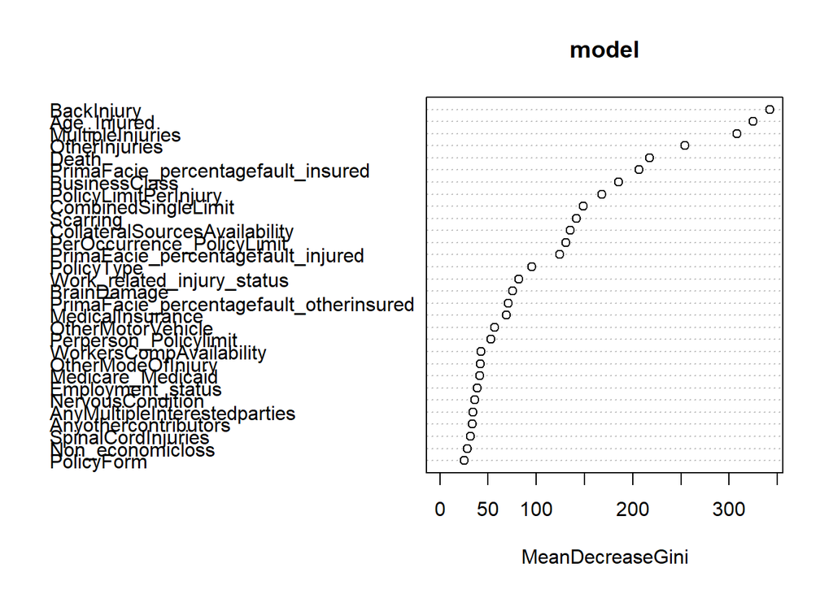

```r
varImpPlot(model)
```

## Predict on Train data

```r
pred_Train = predict(model,
                     train_Data[,setdiff(names(train_Data), "ClaimSize")],
                     type="response",
                     norm.votes=TRUE)
```

## Build confusion matrix and find accuracy

```r
cm_Train = table("actual"= train_Data$ClaimSize, "predicted" = pred_Train);
cm_Train
```

```
##                    predicted
## actual              100K-lessthan200K 200KandAbove lessthan100K
##   100K-lessthan200K              1799          107          728
##   200KandAbove                      8         1526          713
##   lessthan100K                      4           96         5110
```

```r
accu_Train= sum(diag(cm_Train))/sum(cm_Train)
accu_Train
```

```
## [1] 0.8358934
```

```r
rm(pred_Train, cm_Train)
```

## Predict on Test and Calculate Accuracy

```r
# Predicton Test Data
pred_Test = predict(model, test_Data[,setdiff(names(test_Data),
                                              "ClaimSize")],
                    type="response",
                    norm.votes=TRUE)

# Build confusion matrix and find accuracy
cm_Test = table("actual"=test_Data$ClaimSize, "predicted"=pred_Test);
cm_Test
```

```
##                    predicted
## actual              100K-lessthan200K 200KandAbove lessthan100K
##   100K-lessthan200K               580          107          447
##   200KandAbove                     57          425          493
##   lessthan100K                     21          103         2093
```

```r
accu_Test= sum(diag(cm_Test))/sum(cm_Test)
accu_Test
```

```
## [1] 0.716135
```

```r
rm(pred_Test, cm_Test)

accu_Train
```

```
## [1] 0.8358934
```

```r
accu_Test
```

```
## [1] 0.716135
```

## Build random forest using top 12 important attributes

```r
top_Imp_Attr = as.character(rf_Imp_Attr$Attributes[1:12])

set.seed(015)

# Build the classification model using randomForest
model_Imp = randomForest(ClaimSize~.,
                         data=train_Data[,c(top_Imp_Attr,"ClaimSize")],
                         keep.forest=TRUE,ntree=100)
```

## Print and understand the model

```r
print(model_Imp)
```

```
##
## Call:
##  randomForest(formula = ClaimSize ~ ., data = train_Data[, c(top_Imp_Attr,      "ClaimSize")], keep.forest = TRUE, ntree = 100)
##                Type of random forest: classification
##                      Number of trees: 100
## No. of variables tried at each split: 3
##
##         OOB estimate of  error rate: 29.51%
## Confusion matrix:
##                   100K-lessthan200K 200KandAbove lessthan100K class.error
## 100K-lessthan200K              1276          186         1172  0.51556568
## 200KandAbove                    131          886         1230  0.60569648
## lessthan100K                     41          218         4951  0.04971209
```

```r
table(train_Data$target)
```

```
## < table of extent 0 >
```

## Important attributes

```r
model_Imp$importance
```

```
##                                    MeanDecreaseGini
## BackInjury                                 374.4237
## Age_Injured                                459.1010
## MultipleInjuries                           359.5477
## OtherInjuries                              300.7720
## Death                                      246.2438
## PrimaFacie_percentagefault_insured         338.1203
## BusinessClass                              253.1173
## PolicyLimitPerInjury                       207.5942
## CombinedSingleLimit                        187.3012
## Scarring                                   161.4873
## CollateralSourcesAvailability              233.5532
## PerOccurrence_PolicyLimit                  161.5671
```

## Predict on Train Data and Calculate Accuracy

```r
# Predict on Train data
pred_Train = predict(model_Imp, train_Data[,top_Imp_Attr],
                     type="response", norm.votes=TRUE)


# Build confusion matrix and find accuracy
cm_Train = table("actual" = train_Data$ClaimSize,
                 "predicted" = pred_Train);
cm_Train
```

```
##                    predicted
## actual              100K-lessthan200K 200KandAbove lessthan100K
##   100K-lessthan200K              1416          149         1069
##   200KandAbove                     73         1155         1019
##   lessthan100K                      4          123         5083
```

```r
accu_Train_Imp = sum(diag(cm_Train))/sum(cm_Train)
accu_Train_Imp
```

```
## [1] 0.7584977
```

```r
rm(pred_Train, cm_Train)
```

## Predict on Test Data and Calculate Accuracy

```r
# Predicton Test Data
pred_Test = predict(model_Imp, test_Data[,top_Imp_Attr],
                    type="response", norm.votes=TRUE)

# Build confusion matrix and find accuracy
cm_Test = table("actual" = test_Data$ClaimSize,
                "predicted" = pred_Test);
cm_Test
```

```
##                    predicted
## actual              100K-lessthan200K 200KandAbove lessthan100K
##   100K-lessthan200K               551           82          501
##   200KandAbove                     52          373          550
##   lessthan100K                     10           91         2116
```

```r
accu_Test_Imp = sum(diag(cm_Test))/sum(cm_Test)

rm(pred_Test, cm_Test)

accu_Train
```

```
## [1] 0.8358934
```

```r
accu_Test
```

```
## [1] 0.716135
```

```r
accu_Train_Imp
```

```
## [1] 0.7584977
```

```r
accu_Test_Imp
```

```
## [1] 0.7027277
```

## Select mtry value with minimum out of bag (OOB) error.

```r
str(train_Data[57])
```

```
## 'data.frame':    10091 obs. of  1 variable:
##  $ ClaimSize: Factor w/ 3 levels "100K-lessthan200K",..: 3 3 1 2 1 3 3 3 3 3 ...
```

```
## mtry = 7  OOB error = 27.72%
## Searching left ...
## mtry = 5     OOB error = 28.87%
## -0.04147301 0.01
## Searching right ...
## mtry = 10    OOB error = 27.34%
## 0.01358598 0.01
## mtry = 15    OOB error = 27.94%
## -0.02174701 0.01
```

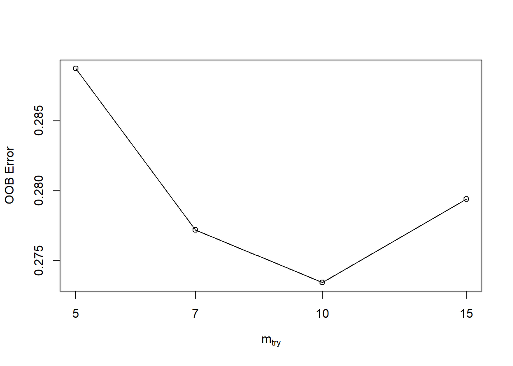

```r
mtry <- tuneRF(train_Data[-57],train_Data$ClaimSize, ntreeTry=100,
               stepFactor=1.5,improve=0.01, trace=TRUE, plot=TRUE)
```

```r
best.m <- mtry[mtry[, 2] == min(mtry[, 2]), 1]
print(mtry)
```

```
##        mtry  OOBError
## 5.OOB     5 0.2886731
## 7.OOB     7 0.2771777
## 10.OOB   10 0.2734120
## 15.OOB   15 0.2793578
```

```r
print(best.m)
```

```
## [1] 10
```

## Tuning Random Forest Models

- Hyper parameters are variables in a model arrived at through empirical methods
- What are the hyper parameters of Random Forest Models?
  - Number of trees to be built
  - Depth of trees
  - Number of columns to use for tree building (Mtry)

## Parameters in tuneRF function

- The stepFactor specifies at each iteration, mtry is inflated (or deflated) by this value
- The improve specifies the (relative) improvement in OOB error must be by this much for the search to continue
- The trace specifies whether to print the progress of the search
- The plot specifies whether to plot the OOB error as function of mtry

## Build Model with best mtry again

```r
 set.seed(71)

rf <- randomForest(ClaimSize~.,data=train_Data, mtry=best.m, importance=TRUE,ntree=100)
print(rf)
```

```
##
## Call:
##  randomForest(formula = ClaimSize ~ ., data = train_Data, mtry = best.m,      importance = TRUE, ntree = 100)
##                Type of random forest: classification
##                      Number of trees: 100
## No. of variables tried at each split: 10
##
##         OOB estimate of  error rate: 27.96%
## Confusion matrix:
##                   100K-lessthan200K 200KandAbove lessthan100K class.error
## 100K-lessthan200K              1406          244          984  0.46621109
## 200KandAbove                    163         1065         1019  0.52603471
## lessthan100K                     97          314         4799  0.07888676
```

## Important attributes - New Model

```r
# Evaluate variable importance
importance(rf)
```

```
##                                            100K-lessthan200K 200KandAbove
## Age_Injured                                      -0.20809024  -0.92973490
## Amputation                                        4.36221922   4.17823473
## Death                                             9.47999585  56.35453453
## Burns_heat                                        2.51096870   2.39327110
## Burns_chemical                                    0.03309815   6.27928609
## SystemicPoisoning_toxic                           2.75348973   0.17270483
## Eye_injury_blindness                              5.63282052   2.53167900
## RespiratoryCondition                              6.78377779   2.03475938
## NervousCondition                                 17.48975158  13.17148096
## HearingLoss                                       6.68904915   2.65946718
## CirculatoryCondition                              7.80077505  10.82021882
## MultipleInjuries                                 47.38978082  23.81602757
## BackInjury                                       53.95686475  24.88860382
## SkinDisorder                                      4.72891455   5.57908087
## BrainDamage                                      17.30739153  24.14099883
## Scarring                                         52.40001411  31.87533247
## SpinalCordInjuries                               14.58936031   9.97350045
## OtherInjuries                                    50.06636759  18.94328818
## OffRoadVehicle                                   -1.73999834   0.08437493
## AirTransportation                                 0.00000000  -1.00503782
## Railway                                           2.15840554   2.85574203
## OtherMotorVehicle                                 5.22328022   0.50203104
## SurgicalCare                                      1.68942441   5.23850739
## Drowning                                         -0.60037738  -0.78868237
## UseOfDefectiveProduct                            -2.38755108   1.17701996
## Fire                                              1.82490873   3.78427485
## Firearm                                           0.00000000  -1.75492122
## Pollution_ToxicExposure                          -0.77485725  -0.39417462
## Explosions                                       -0.21010834   5.92541309
## UseOfAgrlMachinery                                0.00000000   0.00000000
## Oil_gasExtraction                                 0.58485249   3.24142155
## OtherModeOfInjury                                 5.09821295  -2.00688953
## Anyothercontributors                             -1.17140630   0.95949432
## AnyMultipleInterestedparties                      0.89120488   3.01336585
## PrimaFacie_percentagefault_injured                8.03236084   2.11981952
## PrimaFacie_percentagefault_insured               19.94461329  11.04884873
## PrimaFacie_percentagefault_otherinsured           5.79460939   6.19280758
## PrimaFacie_percentagefault_uninsured              1.94842629   0.47614671
## PolicyType                                        4.75317954   5.83294667
```

[output cut: 177 more lines]

```
## PerOccurrence_PolicyLimit                       160.4821606
## CombinedSingleLimit                             190.5206836
## PolicyLimitPerInjury                            216.2897292
## Work_related_injury_status                      100.5918870
## Non_economicloss                                 30.5082453
## Exemplarydamages                                  2.0403028
## WhetherPrimaFacie_JointandSeveralLiability        1.6815155
## WorkersCompAvailability                          49.5637929
## CollateralSourcesAvailability                   149.7565454
## MedicalInsurance                                 71.7093189
## DisabilityInsurance                              11.8337097
## SocialSecurityBenefits                           12.1857910
## Medicare_Medicaid                                36.2790451
## OtherCollateralSources                           13.2106921
## Employment_status                                50.2771785
```

```r
# Important attributes
model$importance
```

```
##                                            MeanDecreaseGini
## Age_Injured                                     325.1497792
## Amputation                                       17.1559655
## Death                                           217.6420036
## Burns_heat                                       17.4917491
## Burns_chemical                                    9.9423912
## SystemicPoisoning_toxic                           4.2350644
## Eye_injury_blindness                             19.3217545
## RespiratoryCondition                             15.7791012
## NervousCondition                                 35.9864222
## HearingLoss                                      12.4287256
## CirculatoryCondition                             22.6171147
## MultipleInjuries                                308.0789036
## BackInjury                                      341.9542330
## SkinDisorder                                     15.4414621
## BrainDamage                                      75.5697388
## Scarring                                        141.5668027
## SpinalCordInjuries                               31.8609189
## OtherInjuries                                   254.2910925
## OffRoadVehicle                                   11.8240558
## AirTransportation                                 0.6616406
## Railway                                           5.9635893
## OtherMotorVehicle                                56.7676500
## SurgicalCare                                     24.2746252
## Drowning                                          2.7791950
## UseOfDefectiveProduct                            15.0554218
## Fire                                              9.9971949
## Firearm                                           2.3394322
## Pollution_ToxicExposure                           2.8656494
## Explosions                                        8.3963518
## UseOfAgrlMachinery                                1.5214680
## Oil_gasExtraction                                 6.4573374
## OtherModeOfInjury                                42.1297312
## Anyothercontributors                             33.8216102
## AnyMultipleInterestedparties                     34.1013921
## PrimaFacie_percentagefault_injured              124.4490630
## PrimaFacie_percentagefault_insured              206.2679644
## PrimaFacie_percentagefault_otherinsured          70.8566934
## PrimaFacie_percentagefault_uninsured             17.4792343
## PolicyType                                       95.1238194
## PolicyForm                                       25.4113440
## BusinessClass                                   185.2509993
## Perperson_Policylimit                            53.0553057
## PerOccurrence_PolicyLimit                       130.4467807
## CombinedSingleLimit                             148.8380046
## PolicyLimitPerInjury                            167.7078295
## Work_related_injury_status                       81.5822375
## Non_economicloss                                 28.4415208
## Exemplarydamages                                  2.0589192
## WhetherPrimaFacie_JointandSeveralLiability        1.6629570
## WorkersCompAvailability                          42.9387044
## CollateralSourcesAvailability                   135.0056560
## MedicalInsurance                                 68.7364614
## DisabilityInsurance                              10.7769321
## SocialSecurityBenefits                           11.3069100
## Medicare_Medicaid                                41.4281938
## OtherCollateralSources                           12.0828853
## Employment_status                                38.7134194
```

## Extract and store important variables obtained from the random forest model

```r
rf_Imp_Attr = data.frame(model$importance)
rf_Imp_Attr = data.frame(row.names(rf_Imp_Attr),rf_Imp_Attr[,1])
colnames(rf_Imp_Attr) = c('Attributes', 'Importance')
rf_Imp_Attr = rf_Imp_Attr[order(rf_Imp_Attr$Importance, decreasing = TRUE),]
```

## Predict on Train Data and Calculate Accuracy

```r
# Predict on Train data
pred_Train = predict(model,
                     train_Data[,setdiff(names(train_Data), "ClaimSize")],
                     type="response",
                     norm.votes=TRUE)

# Build confusion matrix and find accuracy
cm_Train = table("actual"= train_Data$ClaimSize, "predicted" = pred_Train)
cm_Train
```

```
##                    predicted
## actual              100K-lessthan200K 200KandAbove lessthan100K
##   100K-lessthan200K              1796          107          731
##   200KandAbove                      8         1526          713
##   lessthan100K                      4           96         5110
```

```r
accu_Train = sum(diag(cm_Train))/sum(cm_Train)
rm(pred_Train, cm_Train)
```

## Predict on Test Data and Calculate Accuracy

```r
# Predicton Test Data
pred_Test = predict(model, test_Data[,setdiff(names(test_Data),
                                              "ClaimSize")],
                    type="response",
                    norm.votes=TRUE)

# Build confusion matrix and find accuracy
cm_Test = table("actual"=test_Data$ClaimSize, "predicted"=pred_Test)
cm_Test
```

```
##                    predicted
## actual              100K-lessthan200K 200KandAbove lessthan100K
##   100K-lessthan200K               580          106          448
##   200KandAbove                     56          425          494
##   lessthan100K                     21          103         2093
```

```r
accu_Test= sum(diag(cm_Test))/sum(cm_Test)
rm(cm_Test)

accu_Train
```

```
## [1] 0.8355961
```

```r
accu_Test
```

```
## [1] 0.716135
```